# Ejercicios t-SNE

[figure not shown]

*Aprendizaje máquina II*

*Curso 2023-2024*

Authors:

- Rubén Castillo Carrasco

- Manuel Rubio Martínez

Yolanda Vives Gilabert

Este notebook demuestra el funcionamiento básico de la librerías openTSNE y sklearn.TSNE:

https://opentsne.readthedocs.io/en/latest/examples/01_simple_usage/01_simple_usage.html https://scikit-learn.org/stable/modules/generated/sklearn.manifold.TSNE.html

Descargarse el fichero utils de https://github.com/pavlin-policar/openTSNE/blob/master/examples/utils.py

```python
from openTSNE import TSNE
from resources import utils
import numpy as np
from sklearn.model_selection import train_test_split
import matplotlib.pyplot as plt
```

#### Cargar datos

En este ejemplo se utiliza el dataset Macosko 2015, que son datos de retina de ratón. Se trata de un dataset bastante conocido y bastante explorado en la literatura. Se puede obtener en el siguiente enlace: http://file.biolab.si/opentsne/macosko_2015.pkl.gz

```python
import gzip
import pickle

with gzip.open("data/macosko_2015.pkl.gz", "rb") as f:
    data = pickle.load(f)

x = data["pca_50"]
y = data["CellType1"].astype(str)

print("Data set contains %d samples with %d features" % x.shape)
```

```
Data set contains 44808 samples with 50 features
```

#### Crear train/test split

```python
x_train, x_test, y_train, y_test = train_test_split(x, y, test_size=.33, random_state=42)

print("%d training samples" % x_train.shape[0])
print("%d test samples" % x_test.shape[0])
```

```
30021 training samples
14787 test samples
```

#### Run t-SNE

Primero se creará un embedding de los datos. En el siguiente enlace encontrarás los parámetros de entrada de la función tsne.

https://opentsne.readthedocs.io/en/latest/api/index.html

```python
tsne = TSNE(
    perplexity=30,
    metric="euclidean",
    n_jobs=8,
    random_state=42,
    verbose=True,
)
```

```
CPU times: total: 0 ns
Wall time: 0 ns
--------------------------------------------------------------------------------
TSNE(early_exaggeration=12, n_jobs=8, random_state=42, verbose=True)
--------------------------------------------------------------------------------
```

```
===> Finding 90 nearest neighbors using Annoy approximate search using euclidean distance...
   --> Time elapsed: 3.12 seconds
===> Calculating affinity matrix...
   --> Time elapsed: 0.20 seconds
===> Calculating PCA-based initialization...
   --> Time elapsed: 0.06 seconds
===> Running optimization with exaggeration=12.00, lr=2501.75 for 250 iterations...
Iteration   50, KL divergence 5.1602, 50 iterations in 1.3902 sec
Iteration  100, KL divergence 5.0987, 50 iterations in 1.4164 sec
Iteration  150, KL divergence 5.0645, 50 iterations in 1.4103 sec
Iteration  200, KL divergence 5.0505, 50 iterations in 1.4172 sec
Iteration  250, KL divergence 5.0427, 50 iterations in 1.4288 sec
   --> Time elapsed: 7.06 seconds
===> Running optimization with exaggeration=1.00, lr=30021.00 for 500 iterations...
Iteration   50, KL divergence 3.0105, 50 iterations in 1.4607 sec
Iteration  100, KL divergence 2.7979, 50 iterations in 2.3411 sec
Iteration  150, KL divergence 2.7006, 50 iterations in 3.6571 sec
Iteration  200, KL divergence 2.6416, 50 iterations in 5.1512 sec
Iteration  250, KL divergence 2.6009, 50 iterations in 6.0207 sec
Iteration  300, KL divergence 2.5712, 50 iterations in 7.4197 sec
Iteration  350, KL divergence 2.5473, 50 iterations in 8.5598 sec
Iteration  400, KL divergence 2.5286, 50 iterations in 9.3706 sec
Iteration  450, KL divergence 2.5117, 50 iterations in 10.6033 sec
Iteration  500, KL divergence 2.4962, 50 iterations in 11.3499 sec
   --> Time elapsed: 65.94 seconds
```

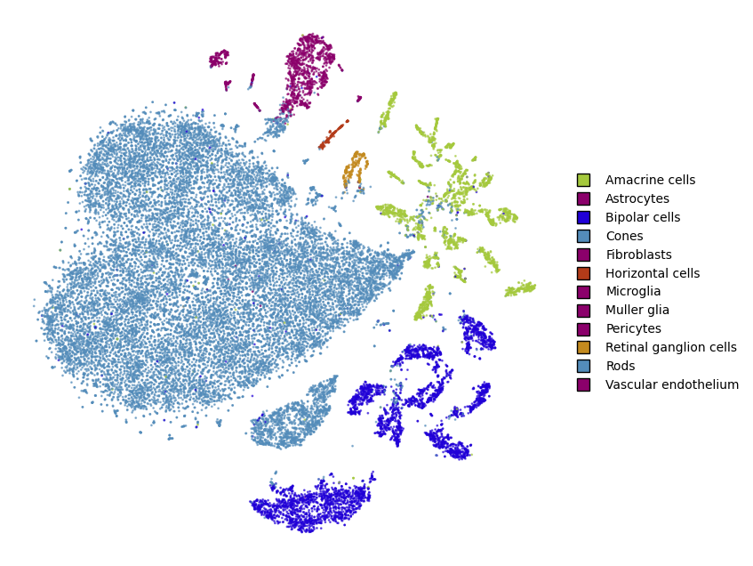

```python
%time
embedding_train = tsne.fit(x_train)
utils.plot(embedding_train, y_train, colors=utils.MACOSKO_COLORS)
```

#### Transformación

Actualmente openTSNE es la única librería que permite meter en el `embedding` nuevos puntos.

```
CPU times: total: 0 ns
Wall time: 0 ns
===> Finding 15 nearest neighbors in existing embedding using Annoy approximate search...
   --> Time elapsed: 0.86 seconds
===> Calculating affinity matrix...
   --> Time elapsed: 0.02 seconds
===> Running optimization with exaggeration=4.00, lr=0.10 for 0 iterations...
   --> Time elapsed: 0.00 seconds
===> Running optimization with exaggeration=1.50, lr=0.10 for 250 iterations...
Iteration   50, KL divergence 213842.5403, 50 iterations in 0.2567 sec
Iteration  100, KL divergence 212310.9428, 50 iterations in 0.2858 sec
Iteration  150, KL divergence 211328.2032, 50 iterations in 0.2892 sec
Iteration  200, KL divergence 210606.5458, 50 iterations in 0.3068 sec
Iteration  250, KL divergence 210062.7909, 50 iterations in 0.2739 sec
   --> Time elapsed: 1.41 seconds
```

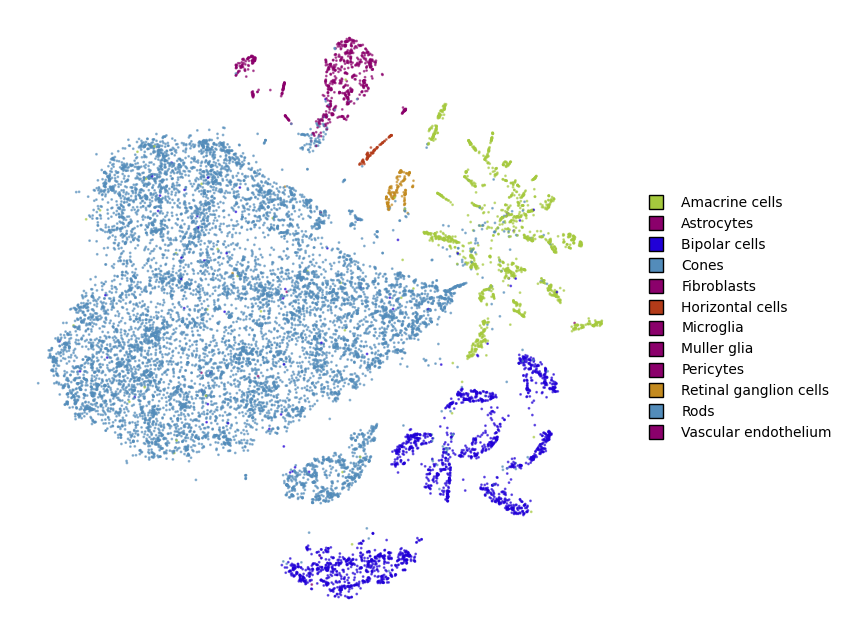

```python
%time
embedding_test = embedding_train.transform(x_test)

utils.plot(embedding_test, y_test, colors=utils.MACOSKO_COLORS)
```

#### Todo junto

Superpone los puntos transformados en el `embedding`original.

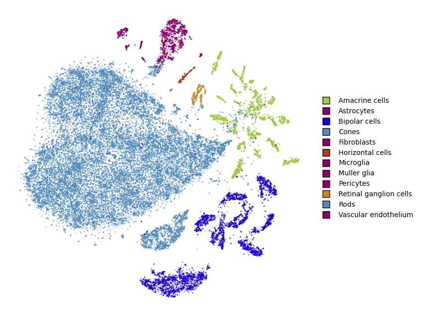

```python
fig, ax = plt.subplots(figsize=(8, 8))
utils.plot(embedding_train, y_train, colors=utils.MACOSKO_COLORS, alpha=0.25, ax=ax)
utils.plot(embedding_test, y_test, colors=utils.MACOSKO_COLORS, alpha=0.75, ax=ax)
```

## Ejercicios con OpenTSNE

Aplica el modelo t-SNE al dataset MNIST.

#### Load data

Load MNIST dataset: https://www.kaggle.com/weiouyang/test-dataset/version/1

```
(60000, 28, 28)
(60000,)
```

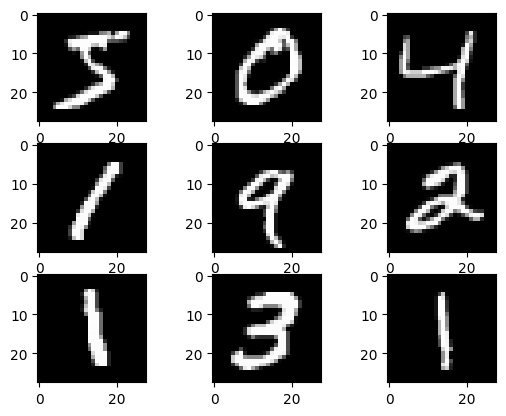

```python
import gzip
import pickle
import sys
import matplotlib.pyplot as plt

f = gzip.open('data/mnist.pkl.gz', 'rb')
if sys.version_info < (3,):
    (X_train, y_train), (X_test, y_test) = pickle.load(f)
else:
    (X_train0, y_train), (X_test0, y_test) = pickle.load(f, encoding="bytes")

print(X_train0.shape)
print(y_train.shape)

for i in range(9):
    plt.subplot(330 + 1 + i)
    plt.imshow(X_train0[i], cmap=plt.get_cmap('gray'))
```

```python
X_train0=X_train0.reshape(60000,-1)

X_train0.shape
```

```
(60000, 784)
```

#### 1.- Empieza ejecutando la función con los valores por defecto (perplexity = 30, early_exaggeration = 12, initialization='pca') para un subconjunto de train del 75% de la muestra.

```python
from sklearn.model_selection import train_test_split

X_train_01, X_train_02, y_train_01, y_train_02 = train_test_split(X_train0, y_train, test_size=0.25, random_state=42)

print(X_train_01.shape)
```

```
(45000, 784)
```

```python
tsne = TSNE(
    perplexity=30,
    early_exaggeration=12,
    initialization='pca',
#    metric="euclidean",
    n_jobs=8,
    random_state=42,
    verbose=True,
)

embedding_train = tsne.fit(X_train_01)
#utils.plot(embedding_train, y_train, colors=utils.MACOSKO_COLORS)
```

```
--------------------------------------------------------------------------------
TSNE(early_exaggeration=12, n_jobs=8, random_state=42, verbose=True)
--------------------------------------------------------------------------------
===> Finding 90 nearest neighbors using Annoy approximate search using euclidean distance...
   --> Time elapsed: 19.05 seconds
===> Calculating affinity matrix...
   --> Time elapsed: 0.72 seconds
===> Calculating PCA-based initialization...
   --> Time elapsed: 0.89 seconds
===> Running optimization with exaggeration=12.00, lr=3750.00 for 250 iterations...
Iteration   50, KL divergence 5.6614, 50 iterations in 1.7584 sec
Iteration  100, KL divergence 5.5525, 50 iterations in 1.7198 sec
Iteration  150, KL divergence 5.5308, 50 iterations in 1.8223 sec
Iteration  200, KL divergence 5.5215, 50 iterations in 1.7529 sec
Iteration  250, KL divergence 5.5154, 50 iterations in 1.6997 sec
   --> Time elapsed: 8.76 seconds
===> Running optimization with exaggeration=1.00, lr=45000.00 for 500 iterations...
Iteration   50, KL divergence 3.2395, 50 iterations in 1.9553 sec
Iteration  100, KL divergence 2.9976, 50 iterations in 3.3202 sec
Iteration  150, KL divergence 2.8758, 50 iterations in 6.1920 sec
Iteration  200, KL divergence 2.7973, 50 iterations in 7.2742 sec
Iteration  250, KL divergence 2.7406, 50 iterations in 7.7732 sec
Iteration  300, KL divergence 2.6971, 50 iterations in 8.8658 sec
Iteration  350, KL divergence 2.6626, 50 iterations in 10.3785 sec
Iteration  400, KL divergence 2.6338, 50 iterations in 11.7010 sec
Iteration  450, KL divergence 2.6094, 50 iterations in 12.9045 sec
Iteration  500, KL divergence 2.5891, 50 iterations in 14.1216 sec
   --> Time elapsed: 84.49 seconds
```

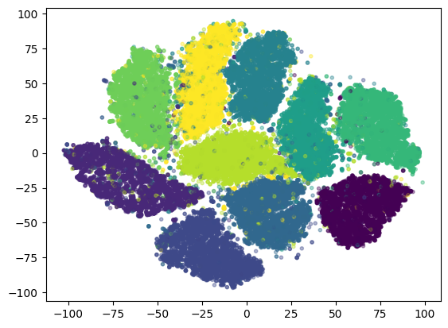

```python
plt.scatter(embedding_train[:,0],embedding_train[:,1],c = y_train_01, alpha = 0.4, marker = ".")
```

Con los hiperparámetros elegidos se puede destacar que el ambedding representa de forma muy buena el conjunto de datos dado, dando lugar a secciones que agrupan los distintas instancias de cada una de las clases.

#### 2.- Ejecuta el modelo sin early_exaggeration (early_exaggeration=1). ¿Qué diferencias observas y a qué se deben?

```python
tsne = TSNE(
    perplexity=30,
    early_exaggeration=1,
    initialization='pca',
    metric="euclidean",
    n_jobs=8,
    random_state=42,
    verbose=True,
)

embedding_train = tsne.fit(X_train_01)
#utils.plot(embedding_train, y_train, colors=utils.MACOSKO_COLORS)
```

```
--------------------------------------------------------------------------------
TSNE(early_exaggeration=1, n_jobs=8, random_state=42, verbose=True)
--------------------------------------------------------------------------------
===> Finding 90 nearest neighbors using Annoy approximate search using euclidean distance...
   --> Time elapsed: 18.98 seconds
===> Calculating affinity matrix...
   --> Time elapsed: 0.66 seconds
===> Calculating PCA-based initialization...
   --> Time elapsed: 0.79 seconds
===> Running optimization with exaggeration=1.00, lr=45000.00 for 250 iterations...
Iteration   50, KL divergence 3.4339, 50 iterations in 1.9956 sec
Iteration  100, KL divergence 3.1556, 50 iterations in 3.1252 sec
Iteration  150, KL divergence 3.0148, 50 iterations in 4.7547 sec
Iteration  200, KL divergence 2.9264, 50 iterations in 6.5847 sec
Iteration  250, KL divergence 2.8639, 50 iterations in 7.5838 sec
   --> Time elapsed: 24.05 seconds
===> Running optimization with exaggeration=1.00, lr=45000.00 for 500 iterations...
Iteration   50, KL divergence 2.8161, 50 iterations in 9.1665 sec
Iteration  100, KL divergence 2.7788, 50 iterations in 9.9456 sec
Iteration  150, KL divergence 2.7479, 50 iterations in 12.5165 sec
Iteration  200, KL divergence 2.7225, 50 iterations in 12.7906 sec
Iteration  250, KL divergence 2.7008, 50 iterations in 14.0483 sec
Iteration  300, KL divergence 2.6821, 50 iterations in 15.5881 sec
Iteration  350, KL divergence 2.6651, 50 iterations in 15.8296 sec
Iteration  400, KL divergence 2.6498, 50 iterations in 17.0294 sec
Iteration  450, KL divergence 2.6368, 50 iterations in 18.6974 sec
Iteration  500, KL divergence 2.6249, 50 iterations in 19.6786 sec
   --> Time elapsed: 145.29 seconds
```

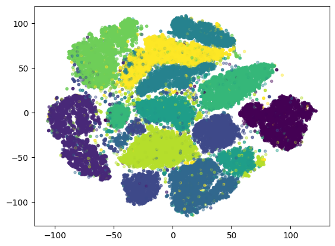

```python
plt.scatter(embedding_train[:,0],embedding_train[:,1],c = y_train_01, alpha = 0.4, marker = ".")
```

La ejecución sin early exaggeration da lugar a una representación donde no se amplifican las diferencias en el espacio de representación de los datos en las primeras etapas del algoritmo, pudiendo ser util para la detección de patrones importantes en el conjunto de datos. En el conjunto de datos dado, su no uso hace que los grupos que agrupan cada una de las clases no queden tan bien definidas frente a las producidas por el embedding que hace uso de early exaggeration, por lo que para el conjunto de datos dado su uso es importante para obtener un embedding de calidad mediante el modelo

#### 3.- Ejecuta el modelo con los valores por defecto pero cambiando la inicialización a `random`. ¿Qué ocurre? ¿Obtenemos mejores o peores resultados que en el caso anterior? Compara también los tiempos de ejecución y comenta porqué difieren.

```python
tsne = TSNE(
    perplexity=30,
    early_exaggeration=12,
    initialization='random',
    metric="euclidean",
    n_jobs=8,
    random_state=42,
    verbose=True,
)

embedding_train = tsne.fit(X_train_01)
```

```
--------------------------------------------------------------------------------
TSNE(early_exaggeration=12, initialization='random', n_jobs=8, random_state=42,
     verbose=True)
--------------------------------------------------------------------------------
===> Finding 90 nearest neighbors using Annoy approximate search using euclidean distance...
   --> Time elapsed: 19.58 seconds
===> Calculating affinity matrix...
   --> Time elapsed: 0.61 seconds
===> Running optimization with exaggeration=12.00, lr=3750.00 for 250 iterations...
Iteration   50, KL divergence 7.0629, 50 iterations in 1.6503 sec
Iteration  100, KL divergence 5.6295, 50 iterations in 1.6473 sec
Iteration  150, KL divergence 5.5525, 50 iterations in 1.7049 sec
Iteration  200, KL divergence 5.5316, 50 iterations in 1.6557 sec
Iteration  250, KL divergence 5.5247, 50 iterations in 1.6376 sec
   --> Time elapsed: 8.30 seconds
===> Running optimization with exaggeration=1.00, lr=45000.00 for 500 iterations...
Iteration   50, KL divergence 3.2632, 50 iterations in 1.9848 sec
Iteration  100, KL divergence 3.0169, 50 iterations in 3.4823 sec
Iteration  150, KL divergence 2.8940, 50 iterations in 5.5688 sec
Iteration  200, KL divergence 2.8147, 50 iterations in 6.7861 sec
Iteration  250, KL divergence 2.7574, 50 iterations in 8.2088 sec
Iteration  300, KL divergence 2.7138, 50 iterations in 9.7239 sec
Iteration  350, KL divergence 2.6785, 50 iterations in 11.1904 sec
Iteration  400, KL divergence 2.6497, 50 iterations in 12.5976 sec
Iteration  450, KL divergence 2.6252, 50 iterations in 14.0497 sec
Iteration  500, KL divergence 2.6048, 50 iterations in 15.9068 sec
   --> Time elapsed: 89.50 seconds
```

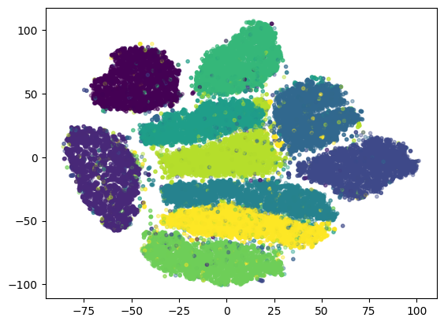

```python
plt.scatter(embedding_train[:,0],embedding_train[:,1],c = y_train_01, alpha = 0.4, marker = ".")
```

El uso del parametro `random` para el modelo dado implica que la elección de las posiciones en la primera de las etapas de cada instancia del conjunto de entrenamiento sea obtenida de forma aleatoria, en lugar de hacer uso de alguna tecnica de inicialización como la vista anteriormente, en este caso pca. Para el conjunto de datos dado esto tiene como resultado un embedding que agrupa bastante bien, aunque no tanto como el inicial, aunque tambien cabe destacar que el resultado obtenido influye de la inicialización aletaria, por lo que un par de ejecuciones con distintas semillas podrían mejorar los resultados.

#### 4.- Ejecuta el modelo con 2 valores muy dispares de perplexity, por ejemplo 1 y 100, (y el resto de valores por defecto) y comenta los resultados.

Primero se prueba con `perplexity=1`

```python
tsne = TSNE(
    perplexity=1,
    early_exaggeration=12,
    initialization='pca',
    metric="euclidean",
    n_jobs=8,
    random_state=42,
    verbose=True,
)

embedding_train = tsne.fit(X_train_01)
```

```
--------------------------------------------------------------------------------
TSNE(early_exaggeration=12, n_jobs=8, perplexity=1, random_state=42,
     verbose=True)
--------------------------------------------------------------------------------
===> Finding 3 nearest neighbors using Annoy approximate search using euclidean distance...
   --> Time elapsed: 10.15 seconds
===> Calculating affinity matrix...
   --> Time elapsed: 0.03 seconds
===> Calculating PCA-based initialization...
   --> Time elapsed: 0.73 seconds
===> Running optimization with exaggeration=12.00, lr=3750.00 for 250 iterations...
Iteration   50, KL divergence 8.0306, 50 iterations in 1.1571 sec
Iteration  100, KL divergence 7.2541, 50 iterations in 1.2764 sec
Iteration  150, KL divergence 6.8805, 50 iterations in 1.2880 sec
Iteration  200, KL divergence 6.6425, 50 iterations in 1.2306 sec
Iteration  250, KL divergence 6.4701, 50 iterations in 1.2306 sec
   --> Time elapsed: 6.18 seconds
===> Running optimization with exaggeration=1.00, lr=45000.00 for 500 iterations...
Iteration   50, KL divergence 5.0627, 50 iterations in 1.5676 sec
Iteration  100, KL divergence 4.5588, 50 iterations in 2.8152 sec
Iteration  150, KL divergence 4.2568, 50 iterations in 4.4516 sec
Iteration  200, KL divergence 4.0413, 50 iterations in 5.8424 sec
Iteration  250, KL divergence 3.8744, 50 iterations in 7.1216 sec
Iteration  300, KL divergence 3.7383, 50 iterations in 8.6787 sec
Iteration  350, KL divergence 3.6237, 50 iterations in 9.5231 sec
Iteration  400, KL divergence 3.5253, 50 iterations in 11.4244 sec
Iteration  450, KL divergence 3.4391, 50 iterations in 12.4468 sec
Iteration  500, KL divergence 3.3619, 50 iterations in 13.4907 sec
   --> Time elapsed: 77.36 seconds
```

A continuación, se hace uso de `perplexity = 100`

```python
tsne2 = TSNE(
    perplexity=100,
    early_exaggeration=12,
    initialization='pca',
    metric="euclidean",
    n_jobs=8,
    random_state=42,
    verbose=True,
)

embedding_train_2 = tsne2.fit(X_train_01)
```

```
--------------------------------------------------------------------------------
TSNE(early_exaggeration=12, n_jobs=8, perplexity=100, random_state=42,
     verbose=True)
--------------------------------------------------------------------------------
===> Finding 300 nearest neighbors using Annoy approximate search using euclidean distance...
   --> Time elapsed: 31.11 seconds
===> Calculating affinity matrix...
   --> Time elapsed: 2.03 seconds
===> Calculating PCA-based initialization...
   --> Time elapsed: 0.74 seconds
===> Running optimization with exaggeration=12.00, lr=3750.00 for 250 iterations...
Iteration   50, KL divergence 4.9143, 50 iterations in 2.5788 sec
Iteration  100, KL divergence 4.9994, 50 iterations in 2.7058 sec
Iteration  150, KL divergence 5.0014, 50 iterations in 2.6859 sec
Iteration  200, KL divergence 5.0013, 50 iterations in 2.6442 sec
Iteration  250, KL divergence 5.0013, 50 iterations in 2.5741 sec
   --> Time elapsed: 13.19 seconds
===> Running optimization with exaggeration=1.00, lr=45000.00 for 500 iterations...
Iteration   50, KL divergence 2.5432, 50 iterations in 2.6777 sec
Iteration  100, KL divergence 2.3899, 50 iterations in 3.6529 sec
Iteration  150, KL divergence 2.3229, 50 iterations in 5.0638 sec
Iteration  200, KL divergence 2.2843, 50 iterations in 6.3950 sec
Iteration  250, KL divergence 2.2571, 50 iterations in 7.3530 sec
Iteration  300, KL divergence 2.2387, 50 iterations in 8.2468 sec
Iteration  350, KL divergence 2.2234, 50 iterations in 9.0627 sec
Iteration  400, KL divergence 2.2118, 50 iterations in 10.0515 sec
Iteration  450, KL divergence 2.2023, 50 iterations in 10.3488 sec
Iteration  500, KL divergence 2.1946, 50 iterations in 11.0696 sec
   --> Time elapsed: 73.93 seconds
```

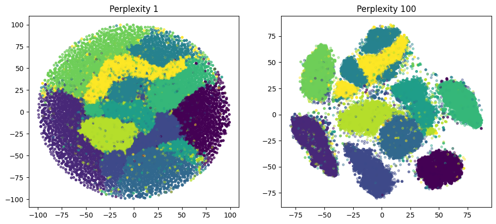

```python
fig, (ax1, ax2) = plt.subplots(1, 2, figsize=(12, 5))

ax1.scatter(embedding_train[:,0],embedding_train[:,1],c = y_train_01, alpha = 0.4, marker = ".")
ax1.set_title("Perplexity 1")


ax2.scatter(embedding_train_2[:,0],embedding_train_2[:,1],c = y_train_01, alpha = 0.4, marker = ".")
ax2.set_title("Perplexity 100")
```

#### 5.- De todas las configuraciones de t-SNE probadas en los ejercicios anteriores, escoge la que mejores resultados obtiene y aplica los datos de test al embedding. Representa el dataset entero.

Se hace uso de la mejor configuración obtenida en el primero de los apartados, que en este caso es la que hace uso de un `perplexity` de 30, junto con `early exageration` de 12 e inicialización mediante `pca`.

```python
tsne = TSNE(
    perplexity=30,
    early_exaggeration=12,
    initialization='pca',
    metric="euclidean",
    n_jobs=8,
    random_state=42,
    verbose=True,
)

embedding_train = tsne.fit(X_train0)
```

```
--------------------------------------------------------------------------------
TSNE(early_exaggeration=12, n_jobs=8, random_state=42, verbose=True)
--------------------------------------------------------------------------------
===> Finding 90 nearest neighbors using Annoy approximate search using euclidean distance...
   --> Time elapsed: 27.01 seconds
===> Calculating affinity matrix...
   --> Time elapsed: 0.81 seconds
===> Calculating PCA-based initialization...
   --> Time elapsed: 0.99 seconds
===> Running optimization with exaggeration=12.00, lr=5000.00 for 250 iterations...
Iteration   50, KL divergence 5.8828, 50 iterations in 2.0888 sec
Iteration  100, KL divergence 5.7318, 50 iterations in 2.2441 sec
Iteration  150, KL divergence 5.6904, 50 iterations in 2.1018 sec
Iteration  200, KL divergence 5.6753, 50 iterations in 2.0784 sec
Iteration  250, KL divergence 5.6672, 50 iterations in 2.0470 sec
   --> Time elapsed: 10.56 seconds
===> Running optimization with exaggeration=1.00, lr=60000.00 for 500 iterations...
Iteration   50, KL divergence 3.4594, 50 iterations in 2.2771 sec
Iteration  100, KL divergence 3.2027, 50 iterations in 3.7271 sec
Iteration  150, KL divergence 3.0732, 50 iterations in 5.4732 sec
Iteration  200, KL divergence 2.9891, 50 iterations in 6.7520 sec
Iteration  250, KL divergence 2.9283, 50 iterations in 8.1500 sec
Iteration  300, KL divergence 2.8814, 50 iterations in 9.5899 sec
Iteration  350, KL divergence 2.8436, 50 iterations in 10.9281 sec
Iteration  400, KL divergence 2.8121, 50 iterations in 12.1668 sec
Iteration  450, KL divergence 2.7852, 50 iterations in 13.2899 sec
Iteration  500, KL divergence 2.7628, 50 iterations in 14.9722 sec
   --> Time elapsed: 87.33 seconds
```

```python
X_test0.shape
```

```
(10000, 28, 28)
```

```python
X_test0=X_test0.reshape(10000,-1)

embedding_test = embedding_train.transform(X_test0)
```

```
===> Finding 15 nearest neighbors in existing embedding using Annoy approximate search...
```

```
   --> Time elapsed: 1.34 seconds
===> Calculating affinity matrix...
   --> Time elapsed: 0.02 seconds
===> Running optimization with exaggeration=4.00, lr=0.10 for 0 iterations...
   --> Time elapsed: 0.00 seconds
===> Running optimization with exaggeration=1.50, lr=0.10 for 250 iterations...
Iteration   50, KL divergence 142355.8090, 50 iterations in 0.1631 sec
Iteration  100, KL divergence 141230.1865, 50 iterations in 0.2183 sec
Iteration  150, KL divergence 140570.8648, 50 iterations in 0.1807 sec
Iteration  200, KL divergence 140132.6316, 50 iterations in 0.1780 sec
Iteration  250, KL divergence 139820.5263, 50 iterations in 0.1672 sec
   --> Time elapsed: 0.91 seconds
```

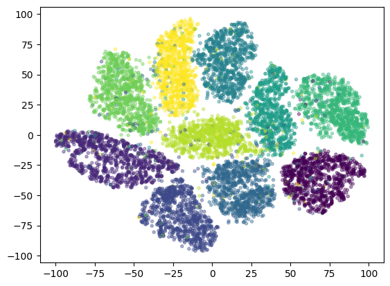

```python
plt.scatter(embedding_test[:,0],embedding_test[:,1],c = y_test, alpha = 0.4, marker = ".")
```

Como resultado tenemos que, el embedding entrenado con los datos del conjunto de train agrupa tan bien el conjunto de test como lo hizo con propio train. Esto es algo muy a tener en cuenta de cara a la elección de un modelo para la obtenición de un embedding, ya que permite inferir la posición de una instancia en un embedding previamente entrenado

## Ejercicios con TSNE de sklearn

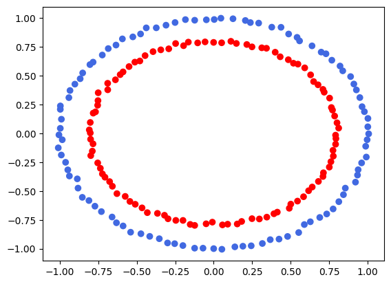

```python
import numpy as np
import matplotlib.pyplot as plt
from sklearn.decomposition import PCA
from sklearn.manifold import TSNE
colors = ['royalblue','red','deeppink', 'maroon', 'mediumorchid', 'tan', 'forestgreen', 'olive', 'goldenrod', 'lightcyan', 'navy']
vectorizer = np.vectorize(lambda x: colors[x % len(colors)])

from sklearn.datasets import make_circles
X, y = make_circles(n_samples=200, noise=0.01)
plt.scatter(X[:,0], X[:,1],c=vectorizer(y))
```

#### 1. Ejecuta t-sne de sklearn con el dataset de los círculos variando la perplexity (valores 5, 30, 100).

```python
import time

tiempos  = []
```

Con perplexity 5 se obtiene:

```python
t1 = time.time()

tsne_5 = TSNE(n_components=2, perplexity=5, random_state=42)
embedding = tsne_5.fit_transform(X)

t2  = time.time()


tiempos.append(t2-t1)
```

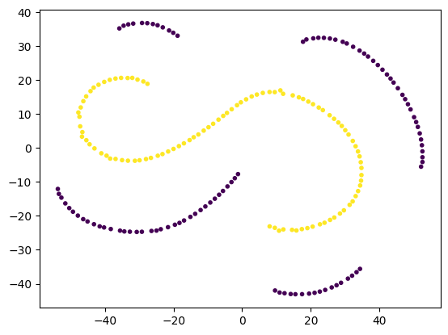

```python
plt.scatter(embedding[:,0],embedding[:,1],c = y, alpha = 1, marker = ".")
```

Con el parámetro dado el embedding no logra representar de forma correcta las relaciones del conjunto de datos. Usando 30 vecinos se obtiene:

```python
t1 = time.time()

tsne_30 = TSNE(n_components=2, perplexity=30, random_state=42)
embedding = tsne_30.fit_transform(X)

t2  = time.time()
tiempos.append(t2-t1)
```

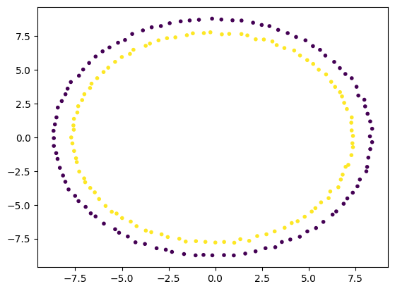

```python
plt.scatter(embedding[:,0],embedding[:,1],c = y, alpha = 1, marker = ".")
```

Con un perplexity de 30, la representación de la realidad es mas fiel al conjunto de datos. Por último se prueba el uso de perplexity = 100

```python
t1 = time.time()

tsne_100 = TSNE(n_components=2, perplexity=100, random_state=42)
embedding = tsne_100.fit_transform(X)

t2  = time.time()
tiempos.append(t2-t1)
```

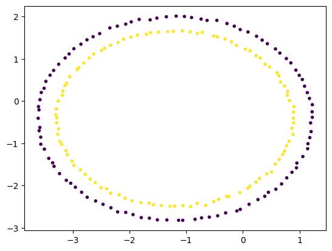

```python
plt.scatter(embedding[:,0],embedding[:,1],c = y, alpha = 1, marker = ".")
```

#### 2. ¿Que KL obtienes en cada caso?

```python
kl_divergence = tsne_5.kl_divergence_
print(f"La divergencia de KL para perplexity de 5 es de {kl_divergence}" )

kl_divergence = tsne_30.kl_divergence_
print(f"La divergencia de KL para perplexity de 5 es de {kl_divergence}" )

kl_divergence = tsne_100.kl_divergence_
print(f"La divergencia de KL para perplexity de 5 es de {kl_divergence}" )
```

[output not shown]

En este caso, el que mejora una mejor representacion de la realidad para el conjunto de datos es el que usa un `perplexity` de 100 teniendo en cuenta la divergencia KL

#### 3. Compara los tiempos de ejecución de Barnes-Hut con el método exacto. Utiliza el valor de perplexity que mejor resultado haya obtenido según el ejercicio anterior.

```python
t1 = time.time()
tsne = TSNE(n_components=2, method='barnes_hut', random_state=42)
embedding = tsne.fit_transform(X)
t2 = time.time()
```

```python
kl_divergence = tsne.kl_divergence_
print(f"La divergencia de KL para perplexity de 5 es de {kl_divergence} usando barnes-hut" )
print(f"El tiempo de ejecución en este caso ha sido de {t2-t1}, frente al de {tiempos[2]} obtenido por el método exacto")
```

[output not shown]

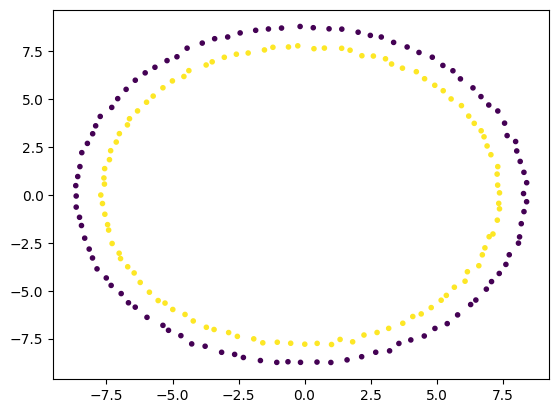

```python
plt.scatter(embedding[:,0],embedding[:,1],c = y, alpha = 1, marker = ".")
```